# Module preservation: HR against LR

Do HR and LR share the same co-expression structure? Modules are built inside each group with the network settings of `01_Processing/06_Module_Building`, then WGCNA’s `modulePreservation()` tests each group’s modules in the other group’s data (Langfelder et al. 2011).

Two statistics come back per module. Zsummary combines how dense and how connected the module is in the other group, against permutations: above 10 is strong preservation, 2 to 10 weak to moderate, below 2 none (Langfelder et al. 2011). The median rank orders modules against each other and does not depend on module size; lower is better preserved. Each group has 8 people and 24 biopsies, so the test has little power to show a module is missing: Zsummary above 2 says the module is found again, not that the two networks are the same.

## Packages

```r
library(here)
library(dplyr)
library(tidyr)
library(purrr)
library(ggplot2)
library(WGCNA)
source(here("00_Setup", "Shared_functions", "workbooks.R"))
disableWGCNAThreads()
inputs <- c(
  corrected = "01_Processing/03_Blood_Correction/c_data/blood_correction.rds",
  modules = "01_Processing/06_Module_Building/c_data/module_building.rds"
)
paths <- vapply(inputs, here, character(1))
stopifnot(file.exists(paths))
```

## Input

The blood-corrected matrix that the full-cohort modules were built on, and those modules.

```r
corrected <- readRDS(paths[["corrected"]])
modules <- readRDS(paths[["modules"]])
abund <- corrected$E
meta <- modules$meta
stopifnot(identical(colnames(abund), meta$sample_id))
count(meta, group, timepoint)
```

```
# A tibble: 6 × 3
  group timepoint     n
  <chr> <chr>     <int>
1 HR    T1            8
2 HR    T2            8
3 HR    T3            8
4 LR    T1            8
5 LR    T2            8
6 LR    T3            8
```

## One network per group

As in `06_Module_Building`, each protein is centred within person, so modules follow within-person variation. `apply()` over proteins returns biopsies in rows, the orientation WGCNA expects. A protein with no spread inside one group cannot be correlated there; `goodSamplesGenes()` finds those, and they are dropped from both groups so the two networks cover the same proteins.

```r
expr <- map(set_names(c("HR", "LR")), \(g) {
  kept <- filter(meta, group == g)
  apply(abund[, kept$sample_id], 1, \(x) x - ave(x, kept$subject))
})
good <- reduce(map(expr, \(x) goodSamplesGenes(x, verbose = 0)$goodGenes), `&`)
expr <- map(expr, \(x) x[, good])
c(dropped = sum(!good), kept = sum(good))
```

```
dropped    kept
      1    2058
```

`build_group()` builds one group’s modules with the `blockwiseModules()` settings and seed of `06_Module_Building`, and the soft power by the same rule: the WGCNA FAQ’s value for a signed network of that many samples (18 below 20, 16 for 20 to 30, 14 for 30 to 40, 12 above 40). Each group has 24 biopsies, so both use 16; the scale-free rule would push them to powers where most proteins fall in no module, as it did for the full network. It returns the power and each protein’s module colour.

```r
bicor_args <- list(corType = "bicor", maxPOutliers = 0.05, pearsonFallback = "individual")
build_group <- function(data) {
  power <- c(18L, 16L, 14L, 12L)[findInterval(nrow(data), c(20, 31, 41)) + 1]
  net <- do.call(blockwiseModules, c(
    list(data,
      power = power, networkType = "signed", TOMType = "signed",
      deepSplit = 2, minModuleSize = 30, mergeCutHeight = 0.15,
      pamStage = TRUE, pamRespectsDendro = TRUE, maxBlockSize = 2500,
      numericLabels = FALSE, randomSeed = 54321, verbose = 0
    ),
    bicor_args
  ))
  list(power = power, colours = set_names(net$colors, colnames(data)))
}
group_modules <- map(expr, build_group)
group_networks <- tibble(
  group = names(group_modules), n_samples = map_int(expr, nrow),
  power = map_int(group_modules, "power"),
  n_modules = map_int(group_modules, \(x) n_distinct(setdiff(x$colours, "grey"))),
  n_unassigned = map_int(group_modules, \(x) sum(x$colours == "grey"))
)
group_networks
```

```
# A tibble: 2 × 5
  group n_samples power n_modules n_unassigned
  <chr>     <int> <int>     <int>        <int>
1 HR           24    16        13          273
2 LR           24    16        16          508
```

## Preservation

Each group is the reference once and the test once, with 200 permutations (seeded). `grey` (unassigned) and `gold` (a random sample WGCNA adds as a baseline) are dropped from the table.

```r
preservation <- modulePreservation(
  multiData = map(expr, \(data) list(data = data)),
  multiColor = map(group_modules, "colours"),
  referenceNetworks = 1:2, networkType = "signed",
  corFnc = "bicor", corOptions = "maxPOutliers = 0.05, pearsonFallback = 'individual'",
  nPermutations = 200, randomSeed = 42, savePermutedStatistics = FALSE, verbose = 0
)
```

Each group module is labelled with the full-cohort module that holds most of its proteins, so the two sets of colour names can be read together.

```r
full <- set_names(modules$membership$module, modules$membership$uniprot_id)
best_match <- imap(group_modules, \(built, g) {
  tibble(group_module = built$colours, full_module = full[names(built$colours)]) |>
    filter(group_module != "grey") |>
    count(group_module, full_module) |>
    mutate(full_share = n / sum(n), .by = group_module) |>
    slice_max(n, n = 1, by = group_module, with_ties = FALSE) |>
    transmute(reference = g, module = group_module, full_module, full_share)
}) |>
  list_rbind()
preservation_table <- map(c(HR = "LR", LR = "HR"), \(test) {
  reference <- setdiff(c("HR", "LR"), test)
  pair <- c(paste0("ref.", reference), paste0("inColumnsAlsoPresentIn.", test))
  z <- preservation$preservation$Z[[pair]]
  tibble(
    reference = reference, test = test, module = rownames(z), n_proteins = z$moduleSize,
    z_summary = z$Zsummary.pres,
    median_rank = preservation$preservation$observed[[pair]]$medianRank.pres
  )
}) |>
  list_rbind() |>
  filter(!module %in% c("grey", "gold")) |>
  left_join(best_match, by = c("reference", "module")) |>
  mutate(preservation = cut(z_summary, c(-Inf, 2, 10, Inf),
    labels = c("none", "weak to moderate", "strong")
  ))
count(preservation_table, reference, test, preservation)
```

```
# A tibble: 4 × 4
  reference test  preservation         n
  <chr>     <chr> <fct>            <int>
1 HR        LR    none                 1
2 HR        LR    weak to moderate    12
3 LR        HR    none                 2
4 LR        HR    weak to moderate    14
```

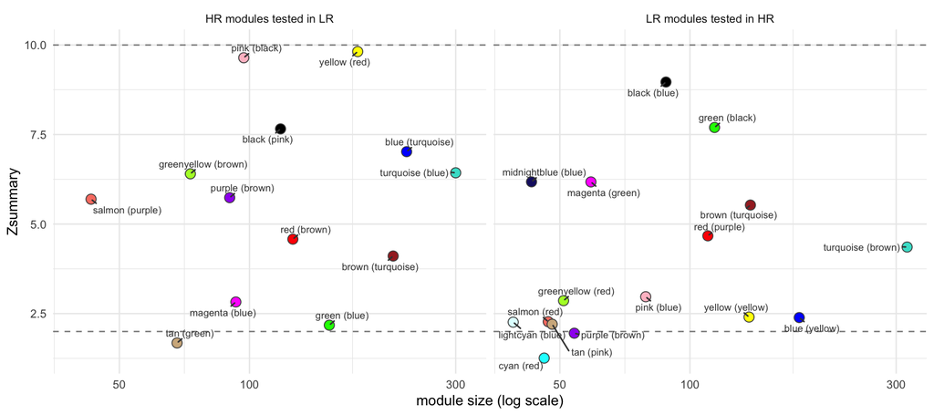

Figure 1: Zsummary of each group’s modules in the other group; dashed: 2 and 10.

```r
preservation_table |>
  mutate(direction = paste(reference, "modules tested in", test)) |>
  ggplot(aes(n_proteins, z_summary)) +
  geom_hline(yintercept = c(2, 10), linetype = "dashed", colour = "grey55") +
  geom_point(aes(fill = module), shape = 21, size = 3, colour = "grey30") +
  ggrepel::geom_text_repel(aes(label = paste0(module, " (", full_module, ")")),
    size = 2.4, seed = 1, colour = "grey25", min.segment.length = 0
  ) +
  facet_wrap(~direction) +
  scale_fill_identity() +
  scale_x_log10() +
  labs(x = "module size (log scale)", y = "Zsummary") +
  theme_minimal(base_size = 10)
```

## Validation

```r
stopifnot(
  setequal(preservation_table$reference, c("HR", "LR")),
  !anyNA(preservation_table$z_summary), !anyNA(preservation_table$full_module),
  all(group_networks$n_samples == 24), all(map_lgl(expr, \(x) ncol(x) == sum(good)))
)
```

## Summary

```r
preservation_table |>
  summarise(n_modules = n(), min_z = min(z_summary), max_z = max(z_summary), .by = reference)
```

```
# A tibble: 2 × 4
  reference n_modules min_z max_z
  <chr>         <int> <dbl> <dbl>
1 HR               13  1.68  9.82
2 LR               16  1.26  8.97
```

HR builds 13 modules at power 16 and LR builds 16 at power 16. Zsummary runs from 1.3 to 9.8; 3 of 29 group modules fall below 2.

## Save

`module_preservation.rds` holds the table and each group’s module colours for the figures.

```r
out <- here("02_HRvLR", "05_Module_Preservation", "c_data")
dir.create(out, showWarnings = FALSE)
group_membership <- imap(group_modules, \(x, g) {
  tibble(group = g, uniprot_id = names(x$colours), module = x$colours)
}) |>
  list_rbind()
saveRDS(
  list(
    preservation = preservation_table, group_networks = group_networks,
    group_membership = group_membership
  ),
  file.path(out, "module_preservation.rds")
)
write_workbook(
  list(
    preservation = preservation_table, group_networks = group_networks,
    group_membership = group_membership
  ),
  c(
    "Zsummary and median rank of each group's modules tested in the other group.",
    "Biopsies, soft power, module count and unassigned proteins of each group's network.",
    "Every protein's module in each group's network."
  ),
  file.path(out, "module_preservation.xlsx"), inputs, paths
)
```